# SVD with optimal rank determination by robustness

Zach DeBruine

11/19/2020

# Objective:

Develop a method for automatic rank determination based on identifying robust SVD factors with bipartite matching.

## Load datasets

We will use a small single-cell RNA-seq dataset from the human embryonic midbrain.

```r
library(scRNAseq)
sce.human <- invisible(LaMannoBrainData("human-embryo"))
```

```r
# extract counts and run SCTransform with Seurat
library(Seurat)
obj <- CreateSeuratObject(counts(sce.human))
obj <- SCTransform(obj, verbose = 0)
```

## Split data into sets

The data must be split into randomly partitioned non-overlapping subsets, and at least two subsets. SVD will be run independently on both of these subsets, and singular vectors will be selected which are robust between independent dimensional reductions. Then, we will generate a “master” SVD at that rank on the entire dataset.

```r
# Split counts into two sets
obj.counts <- GetAssayData(obj, slot = "counts")
sets <- split.into.sets(obj.counts, n.sets = 2, seed = 123)

# scale and center each set independently
sets <- lapply(sets, function(x) scale(x))
```

## Run SVD on each set and measure robustness of factors

We use right-truncated SVD with the irlba package because of it’s efficiency.

To measure robustness, we calculate the cosine distance between factors in both sets.

Like other unit or angular measures (i.e. cosine, chord) it performs very well on latent spaces without being much affected by sparsity (unlike spatial distance measures). Bhjattacharyya distance is slightly more sensitive than the other measures, and is also slightly faster to compute due to fewer matrix operations.

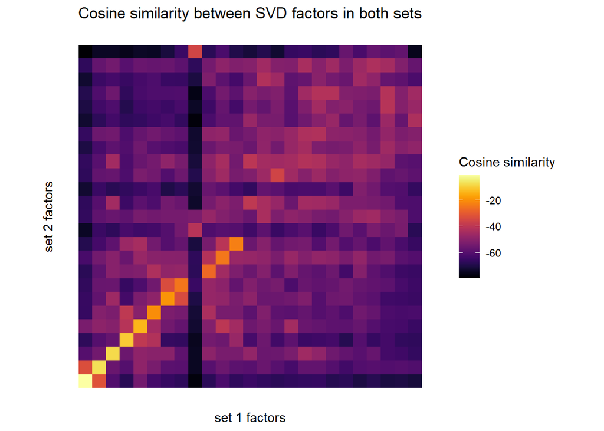

```r
library(irlba)
sets.svd <- lapply(sets, function(x) irlba(x, nv = 25))

library(wordspace)
set1 <- abs(sets.svd[[1]]$u)
set2 <- abs(sets.svd[[2]]$u)
svd.dist <- dist.matrix(set1,set2, byrow = FALSE, method = "cosine")

# view distances between svd$u results in both matrices
gheatmap(1-svd.dist, legend.title = "Cosine similarity", title = "Cosine similarity between SVD factors in both sets", ylab = "set 2 factors", xlab = "set 1 factors", show.ylabs = 0, show.xlabs = 0)
```

## A method for selection of robust SVD factors

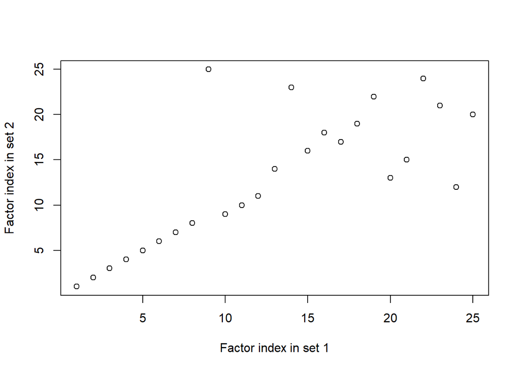

```r
library(RcppHungarian)
matched <- HungarianSolver(svd.dist)$pairs
```

Now calculate the cumulative deviance of one-to-one matching of factors along the SVD diagonal:

```r
cum.deviance <- cumsum((abs(matched[,1] - matched[,2])))
```

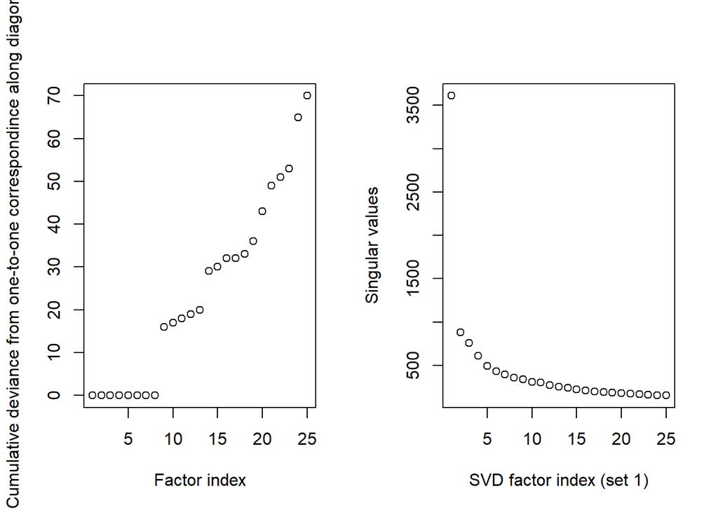

We now determine how many consecutive factors exist in both datasets which are both matched and have equal diagonal indices. We truncate the list of factors at the first deviation, since if they deviate from their diagonal ordering, we know there is significant contaminating noise in any residual signal.

```r
robust.k <- which(cum.deviance > 0)[1] - 1
```

After selecting factors to keep, we run SVD on the entire dataset for that number of factors.

```r
data.scaled <- scale(obj.counts)
data.svd <- irlba(data.scaled, nv = robust.k)
data.svd$u <- abs(data.svd$u)
data.svd$v <- abs(data.svd$v)
rownames(data.svd$u) <- rownames(obj.counts)
rownames(data.svd$v) <- colnames(obj.counts)
colnames(data.svd$u) <- colnames(data.svd$v) <- paste0("factor",1:ncol(data.svd$v))
```

## Packaging up a method for robust SVD feature selection into an accesible function

Package everything above into a convenient function:

```r
#' Run SVD on a matrix with factor selection by bipartite matching along the diagonal. This function makes use of the irlba svd function to perform truncated SVD.
#'
#' @param A A matrix
#' @param scale Should \code{A} be centered and scaled?
#' @param seed seed to set for reproducibility in splitting training sets from A
#' @param verbose print updates to the console
#' @param k How many singular vectors to compute (i.e. nv, where nv = nu)
#' @return List with svd result for input and svd.set1 and svd.set2 result for training sets, each with robust vectors only
robust.svd <- function(A, k, scale = TRUE, seed = NULL, verbose = 1){

    require(irlba)
    require(wordspace)
    require(RcppHungarian)

    if(verbose > 0) cat("Running robust SVD\n")

    if(scale == TRUE) {
      if(verbose > 0) cat("   ...1/8 centering and scaling input\n")
      A <- scale(A)
    }

    if(verbose > 0) cat("   ...2/8 splitting input into two training sets\n")
    if(!is.null(seed)) set.seed(seed)
    indices <- sample(1:ncol(A), floor(ncol(A)/2))

    if(verbose > 0) cat("   ...3/8 running svd on training set 1 with",k,"vectors\n")
    set1.svd <- irlba(A[,indices], nv = k)
    if(verbose > 0) cat("   ...4/8 running svd on training set 2 with",k,"vectors\n")
    set2.svd <- irlba(A[,-indices], nv = k)

    if(verbose > 0) cat("   ...5/8 calculating distances between svd results\n")
    svd.dist <- dist.matrix(sqrt(abs(set1.svd$u)),sqrt(abs(set2.svd$u)), byrow = FALSE, method = "euclidean")

    if(verbose > 0) cat("   ...6/8 matching vectors in both training sets\n")
    matched <- HungarianSolver(svd.dist)$pairs
    colnames(matched) <- c("set1","set2")

    cum.deviance <- cumsum((abs(matched[,1] - matched[,2])))
    robust.k <- which(cum.deviance > 0)[1] - 1
    if(verbose > 0) cat("   ...7/8 number of significant factors:",robust.k,"\n")

    set1.svd$u <- abs(set1.svd$u[,1:robust.k])
    set1.svd$v <- abs(set1.svd$v[,1:robust.k])
    set1.svd$d <- abs(set1.svd$d[1:robust.k])
    set2.svd$u <- abs(set2.svd$u[,1:robust.k])
    set2.svd$v <- abs(set2.svd$v[,1:robust.k])
    set2.svd$d <- abs(set2.svd$d[1:robust.k])

    if(verbose > 0) cat("   ...8/8 running SVD on entire input with nv =", robust.k,"\n")
    A.svd <- irlba(A, nv = robust.k)
    A.svd$u <- abs(A.svd$u)
    A.svd$v <- abs(A.svd$v)
    rownames(set1.svd$u) <- rownames(set2.svd$u) <- rownames(A.svd$u) <- rownames(A)
    rownames(A.svd$v) <- colnames(A)
    colnames(set1.svd$v) <- colnames(set2.svd$v) <- colnames(set1.svd$u) <- colnames(set2.svd$u) <- colnames(A.svd$u) <- colnames(A.svd$v) <- paste0("factor",1:ncol(A.svd$v))
    list("svd" = A.svd, "svd.set1" = set1.svd, "svd.set2" = set2.svd)
}
```

Now run that packaged function on the input dataset:

```r
obj.counts <- GetAssayData(obj, slot = "counts")
svd.result <- robust.svd(obj.counts, k = 25, scale = TRUE, verbose = 1, seed = NULL)$svd
```

```
## Running robust SVD
##    ...1/8 centering and scaling input
##    ...2/8 splitting input into two training sets
##    ...3/8 running svd on training set 1 with 25 vectors
##    ...4/8 running svd on training set 2 with 25 vectors
##    ...5/8 calculating distances between svd results
##    ...6/8 matching vectors in both training sets
##    ...7/8 number of significant factors: 9
##    ...8/8 running SVD on entire input with nv = 9
```

And this is the SVD result:

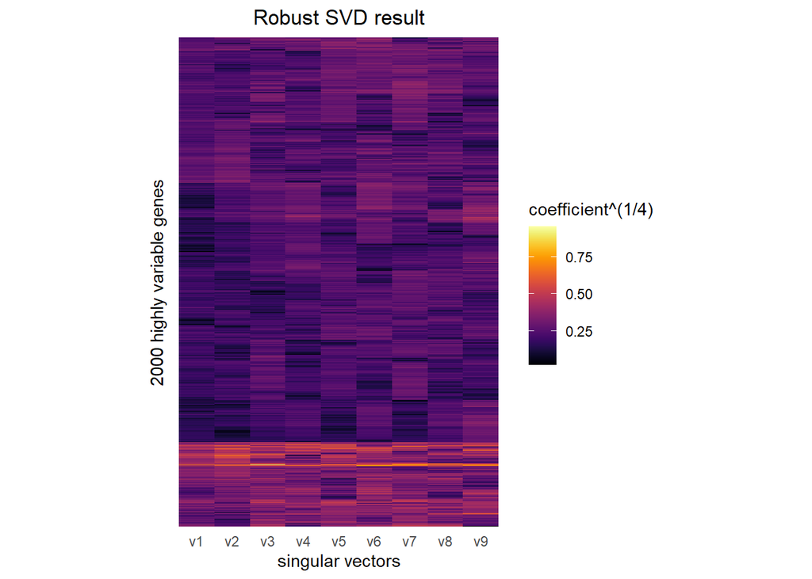

## Future directions:

It may be useful to incorporate some tolerance to cumulative deviance, as there may be meaningful factors which are not exactly aligned along the diagonal. Such a tolerance would likely increase the number of retained factors, but not by much.